# Manejo de Strings

Práctica Guiada

```r
# install.packages("rtweet")
library(rtweet)
library(tidyverse)
library(tm)
library(wordcloud2)
library(RVerbalExpressions)
library(lubridate)
```

## Cargamos la base de tweets

```r
villa_azul_tweets <- readRDS('data/villa_azul_tweets.RDS')
```

Veamos que rango de tiempo abarcan nuestros tweets (8 días)

```r
range(villa_azul_tweets$created_at)
```

```
[1] "2020-05-18 21:17:53 UTC" "2020-05-26 20:31:10 UTC"
```

Qué tipo de variable es **created_at**??

```r
class(villa_azul_tweets$created_at)
```

```
[1] "POSIXct" "POSIXt"
```

Es un tipo de variable de tiempo expresada en zona horaria UTC).

El propio paquete `rtweet` viene con la función **ts_plot** que permite graficar la frecuencia de tweets dado un intervalo temporal.

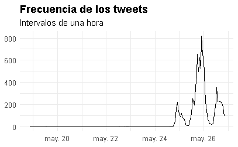

```r
villa_azul_tweets %>%
  ts_plot(by = "hours") +
  theme_minimal() +
  theme(plot.title = ggplot2::element_text(face = "bold")) +
  labs(x = NULL, y = NULL,
       title = "Frecuencia de los tweets",
       subtitle = "Intervalos de una hora")+
  scale_x_datetime()
```

## Lubridate

### Extraccion de informacion de la fecha

El paquete `lubridate` es ideal para trabajar con fechas en R. En primera instancia nos permite extraer muy intuitivamente información cuando contamos con una variable construida como fecha.

```r
villa_azul_fechas <- villa_azul_tweets %>%
  mutate(anio      = year(created_at),
         semestre  = semester(created_at),
         trimestre = quarter(created_at),
         mes       = month(created_at),
         dia.numero= wday(created_at),
         dia.nombre= wday(created_at, label = TRUE),
         hora = hour(created_at),
         minutos = minute(created_at))
```

### Operaciones

El paquete tiene una serie de funciones para operar realizando transformaciones sobre las fechas. Tomemos la fecha del primer registro para operar sobre ella:

```r
fecha <- villa_azul_fechas$created_at[1]
fecha
```

```
[1] "2020-05-26 20:31:10 UTC"
```

```r
fecha+ days(2) # Le sumo dos días a la fecha
```

```
[1] "2020-05-28 20:31:10 UTC"
```

```r
fecha+ days(2) - hours(3)# Le sumo dos días a la fecha y le resto tres horas
```

```
[1] "2020-05-28 17:31:10 UTC"
```

Importante notar que:

- Las funciones para **extraer** informacion de las fechas llevan el singular (ej: day,month,hour)
- Las funciones para **transformar** las fechas llevan el **plural** (ej: days, months,hours)

### Cambios de formato

Suele ocurrir que uno trabaja importando bases de datos donde las variables temporales no traen con el formato necesario para trabajar con fechas en R, o bien el programa no puede codificarlas directametne como fechas. El paquete `lubridate` también tiene una serie de funciones que permiten lidiar con ello.

Veamos algunos ejemplos

```r
ejemplo0 <- "20/05/2020 18:20:40"
ejemplo1 <- "20/05/2020"
ejemplo2 <- "20/05/2020 18:20"
class(ejemplo0)
```

```
[1] "character"
```

Hay un set de funciones que siguen la siguiente lógica:  
Mediante la combinacion de los caracteres **dmy_hms** podemos convertir un string a una fecha, indicando que el formato en que nuestro string tiene la codificada la fecha. En el ejemplo0, es día(d), mes(m), año(y), hora(h), minuto(m) y segundo(s)

```r
ejemplo0_formateado <- dmy_hms(ejemplo0)
ejemplo0_formateado
```

```
[1] "2020-05-20 18:20:40 UTC"
```

Que tipo de objeto es ahora *ejemplo0_formateado*?

```r
class(ejemplo0_formateado)
```

```
[1] "POSIXct" "POSIXt"
```

Para resolver los otros ejemplos, seguimos la misma lógica. Por ejemplo en el caso 1, solo tenemos day, month, year. Para ello aplicaremos la función **dmy**

```r
ejemplo1_formateado <- dmy(ejemplo1)
ejemplo1_formateado
```

```
[1] "2020-05-20"
```

Ejemplo 2:

```r
ejemplo2_formateado <- dmy_hm(ejemplo2)
ejemplo2_formateado
```

```
[1] "2020-05-20 18:20:00 UTC"
```

Para formatos un poco menos estandarizados, la función parse_date_time nos puede ser útil para transforar una variable.

```r
dato_importado <- c("Apr-20","May-20","Jun-20")
parse_date_time(dato_importado, orders = 'my')
```

```
[1] "2020-04-01 UTC" "2020-05-01 UTC" "2020-06-01 UTC"
```